# Étude des caractéristiques de course

Observation statistique

Auteur·rice

Robin Maël

Date de publication

23 mars 2026

Mots clés

Amplitude, Fréquence, Sprint, Optimisation

# Observation Graphique

**DV**

**Razet**

#### Profil Amplitude - Fréquence

Toutes les corrélations ont été réalisées avec la méthode de Spearman car les données ne suivent pas une répartition normale.

J’ai posé :

- Si p < 0.001 = “***” ;
- Si p < 0.01 = “**” ;
- Si p < 0.05 = “*” ;
- Sinon p = “ns”

##### Graphiques

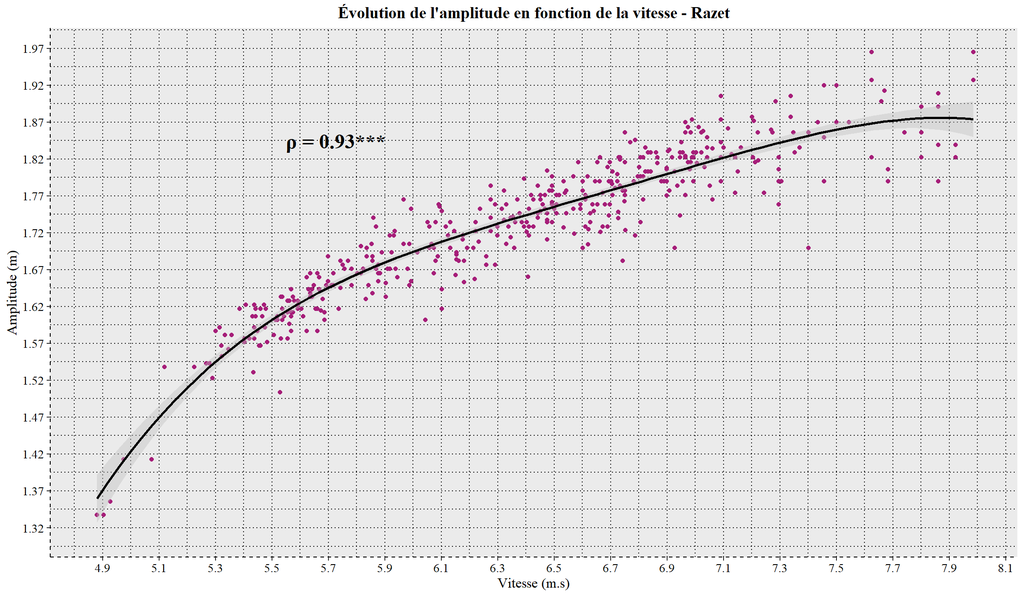

Graphique n°1 : Évolution de l’amplitude en fonction de la vitesse - Razet

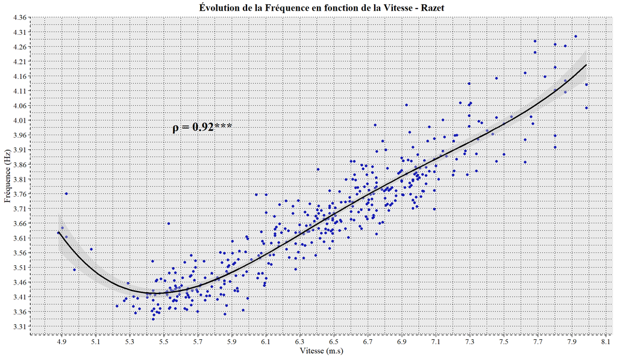

Graphique n°2 : Évolution de la Fréquence en fonction de la Vitesse - Razet

On observe de manière très **significative** une **corrélation forte positive** entre la **Vitesse** et l’**Amplitude**, et entre la **Vitesse** et la **Fréquence**.

La différence entre le r de l’amplitude et le r de la fréquence nous donne un estimate de 0.01.

C’est un profil presque parfaitement équilibré.

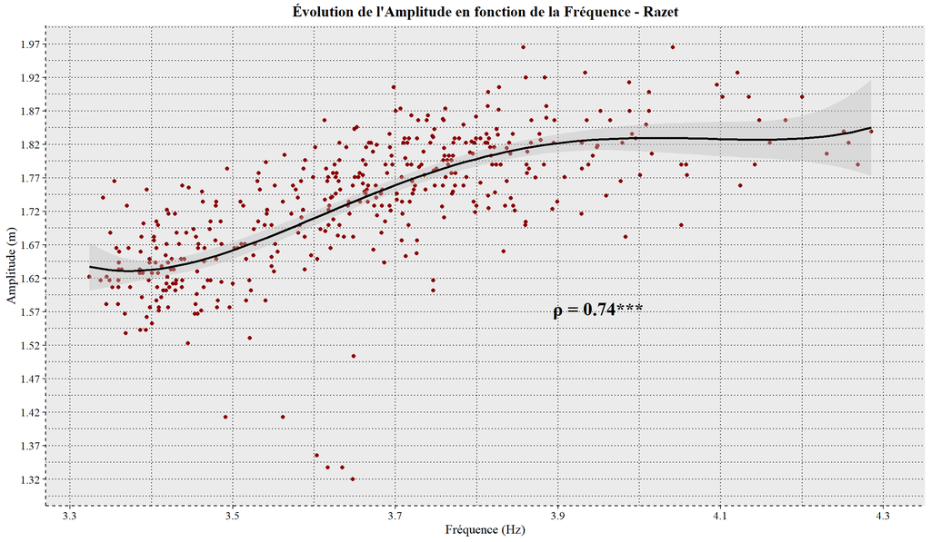

On observe une corrélation très significative forte entre l’Amplitude et la Fréquence.

**Logette**

#### Profil Amplitude - Fréquence

##### Graphiques

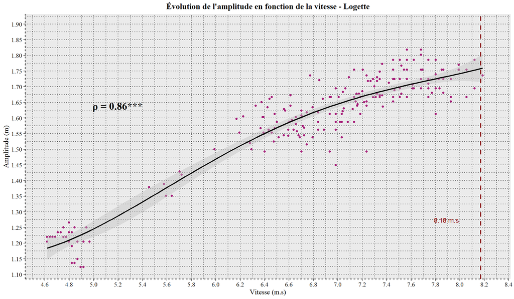

Graphique n°4 : Évolution de l’amplitude en fonction de la vitesse - Logette

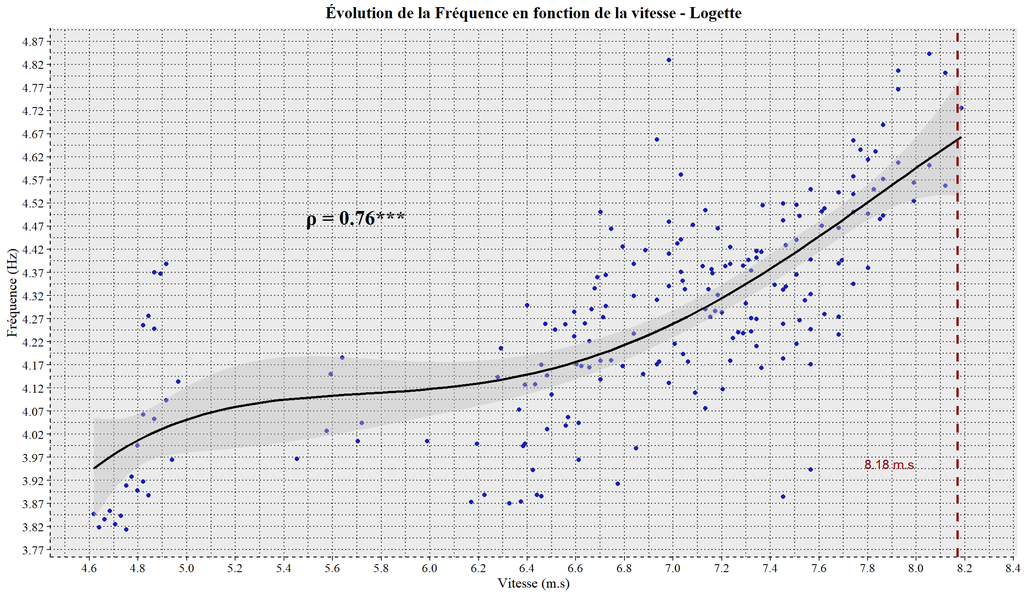

Graphique n°5 : Évolution de la Fréquence en fonction de la Vitesse - Logette

Chez Tiff on remarque des corrélations positives très significatives un peu moins fortes. On remarque que la corrélation est légèrement plus forte entre l’Amplitude et la Vitesse.

On a un estimate de 0.1.

[figure not shown]

On observe un PFV plutôt équilibré. L’idée cela va être de déterminer si le PFV est en Vitesse ou en Force grâce au coefficient de la pente F-V. Ce qui va nous permettre d’avoir 3 catégories de PFV : Force - Neutre - Vitesse et 3 catégories de PAF : Fréquence - Neutre - Amplitude.

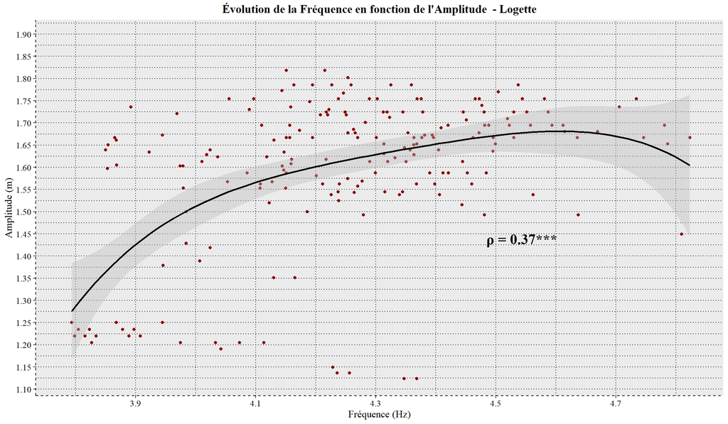

Graphique n°6 : Évolution de la Fréquence en fonction de l’Amplitude - Logette

**Thebault**

#### Profil Amplitude - Fréquence

##### Graphiques

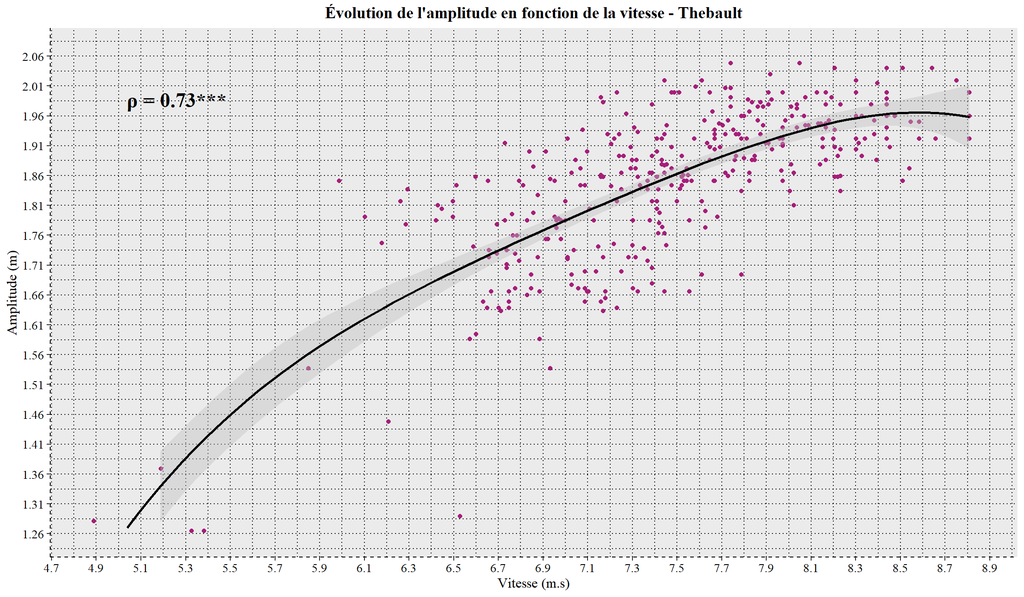

Graphique n°7 : Évolution de l’amplitude en fonction de la vitesse - Thebault

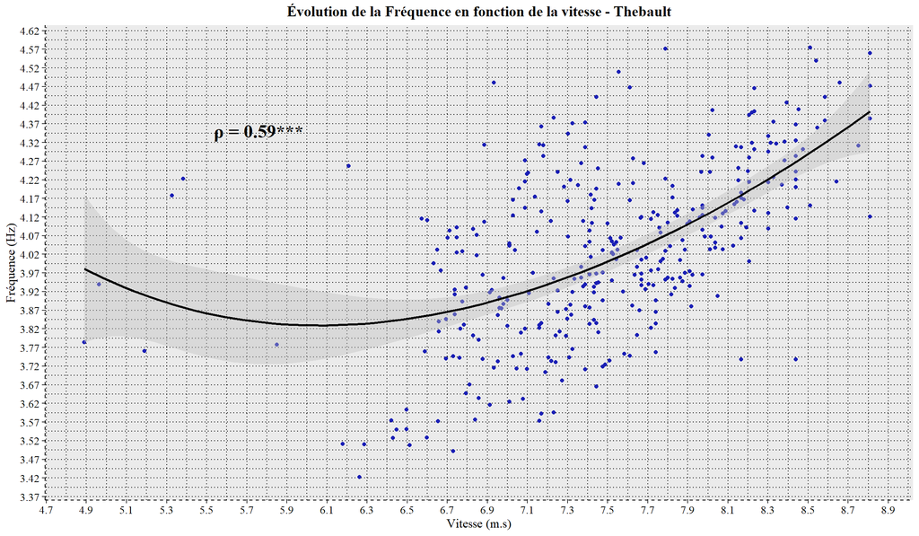

Graphique n°8 : Évolution de la Fréquence en fonction de la Vitesse - Thebault

Chez Evan on remarque encore des corrélations très significatives. Mais ici beaucoup moins marquées entre la Fréquence et la Vitesse.

On a un estimate de 0.14. Un peu plus marqué vers l’amplitude.

En attente du PFV.

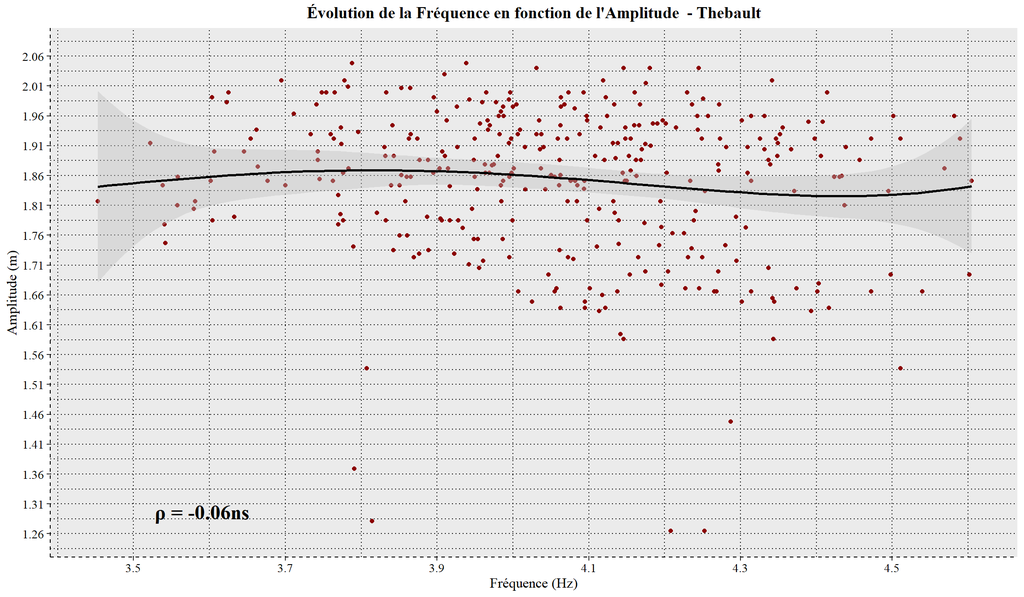

Graphique n°9 : Évolution de la Fréquence en fonction de l’Amplitude - Thebault

**Makunda**

#### Profil Amplitude - Fréquence

##### Graphiques

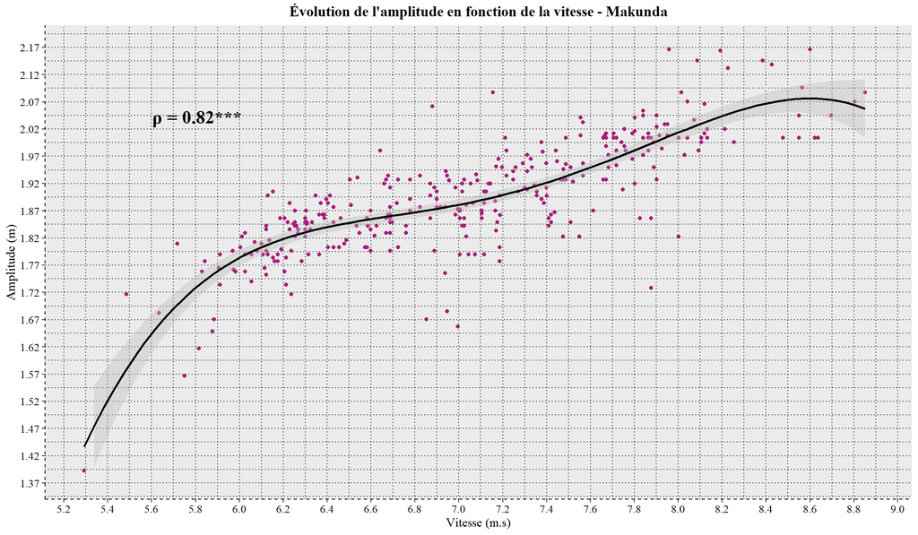

Graphique n°10 : Évolution de l’amplitude en fonction de la vitesse - Makunda

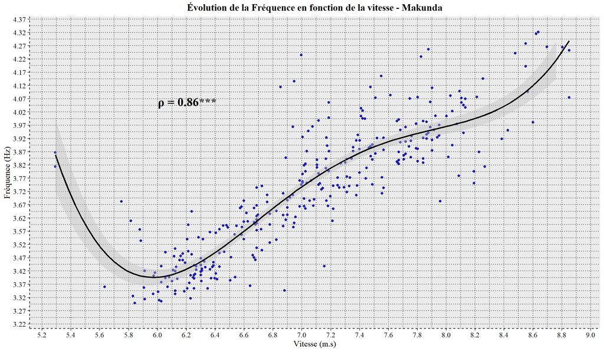

Graphique n°11 : Évolution de la Fréquence en fonction de la Vitesse - Makunda

Chez Trésor pour terminer on observe des corrélations positives très significatives. Les deux sont très fortes et quasi équivalentes.

On a un estimate de -0.04.

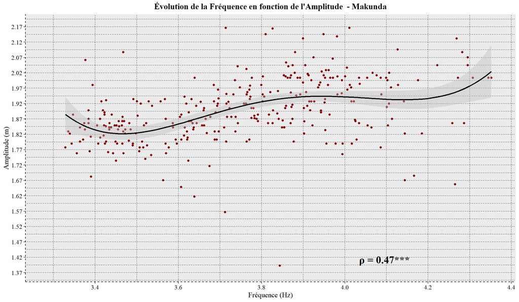

Graphique n°12 : Évolution de la Fréquence en fonction de l’Amplitude - Makunda

**Cumulé**

#### Profil Amplitude - Fréquence

##### Graphiques

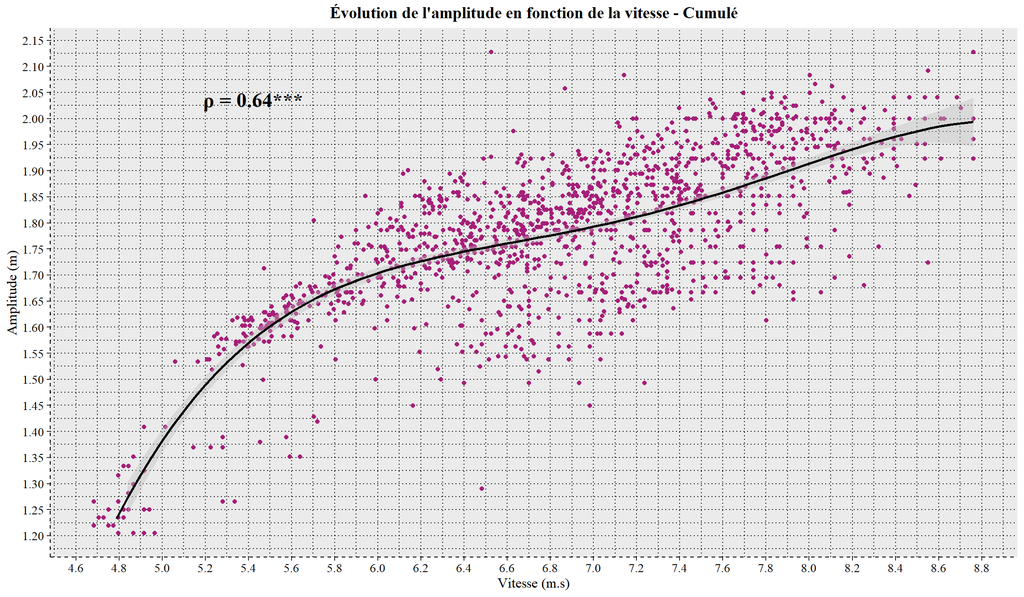

Graphique n°13 : Évolution de l’amplitude en fonction de la vitesse - Cumulé

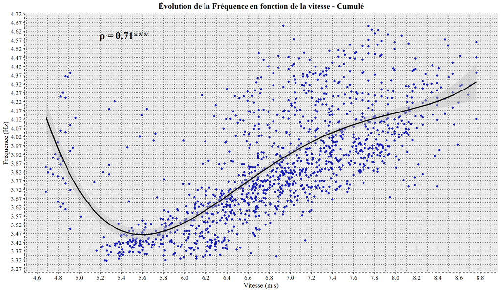

Graphique n°14 : Évolution de la Fréquence en fonction de la vitesse - Cumulé

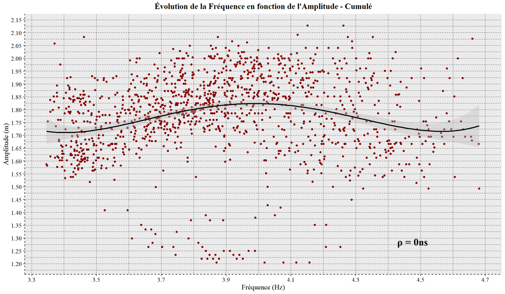

Graphique n°15 : Évolution de la Fréquence en fonction de l’Amplitude - Cumulé

**Guides**

**Mathonat**

#### Profil Amplitude - Fréquence

##### Graphiques

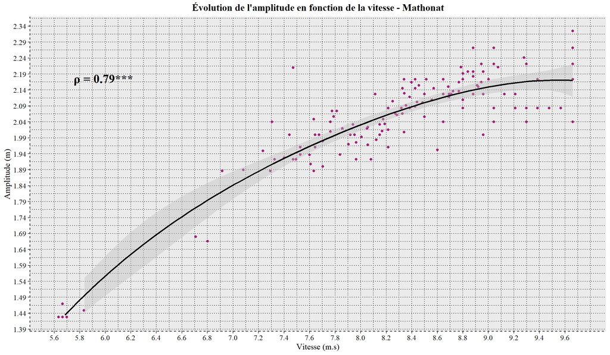

Graphique n°16 : Évolution de l’amplitude en fonction de la vitesse - Mathonat

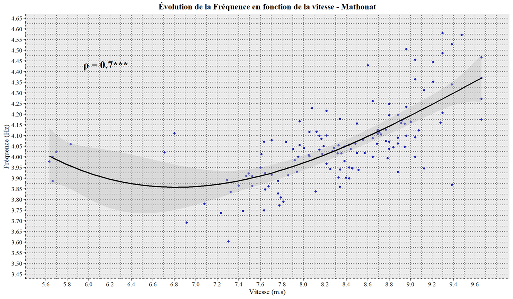

Graphique n°17 : Évolution de la Fréquence en fonction de la Vitesse - Mathonat

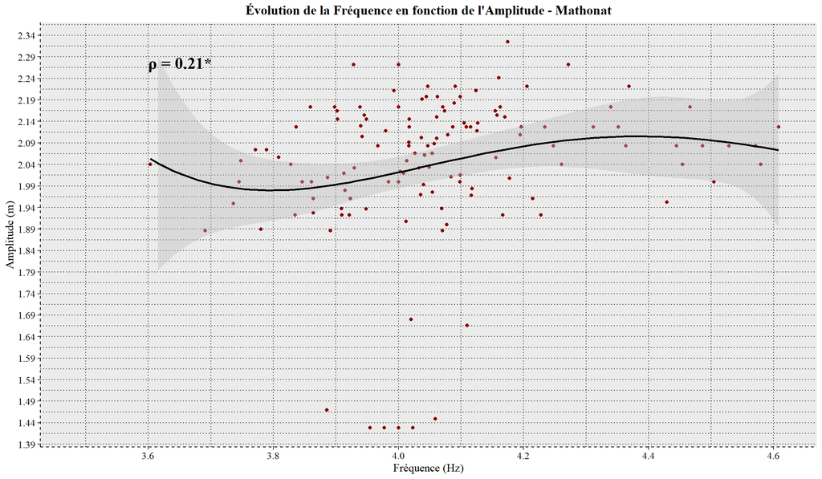

Graphique n°18 : Évolution de la Fréquence en fonction de l’Amplitude - Mathonat

**Berland**

#### Profil Amplitude - Fréquence

##### Graphiques

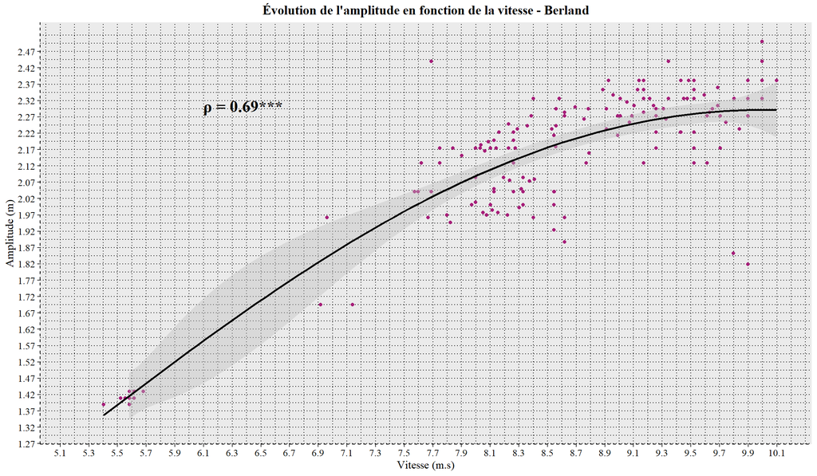

Graphique n°19 : Évolution de l’amplitude en fonction de la vitesse - Berland

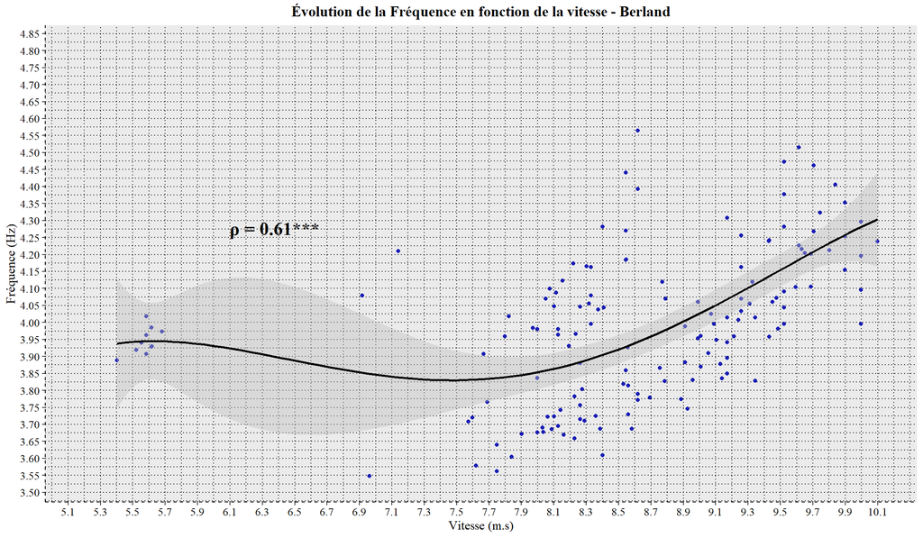

Graphique n°20 : Évolution de la Fréquence en fonction de la Vitesse - Berland

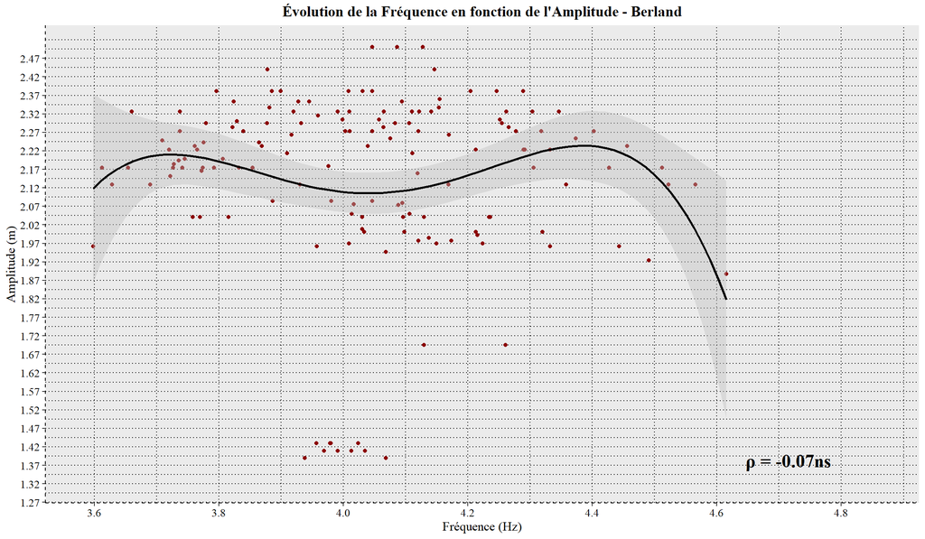

Graphique n°21 : Évolution de la Fréquence en fonction de l’Amplitude - Berland

**Le Rolland**

#### Profil Amplitude - Fréquence

##### Graphiques

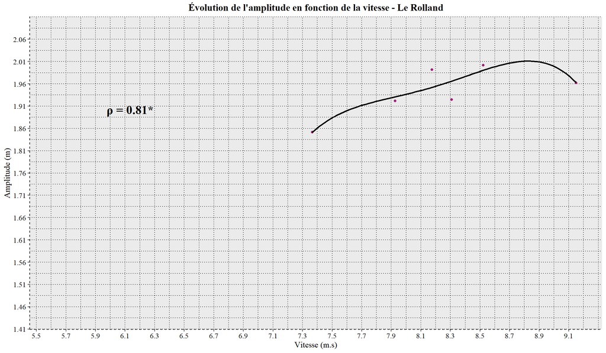

Graphique n°22 : Évolution de l’amplitude en fonction de la vitesse - Le Rolland

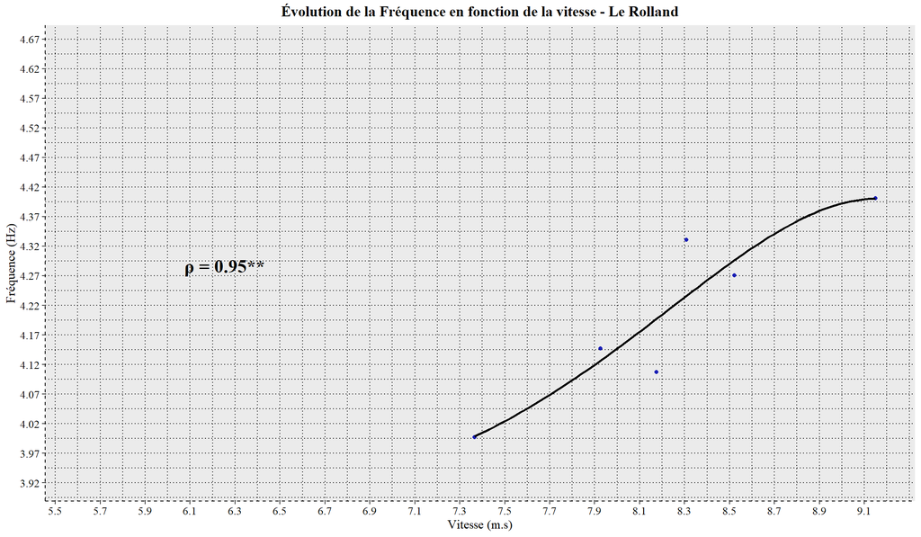

Graphique n°23 : Évolution de la Fréquence en fonction de la Vitesse - Le Rolland

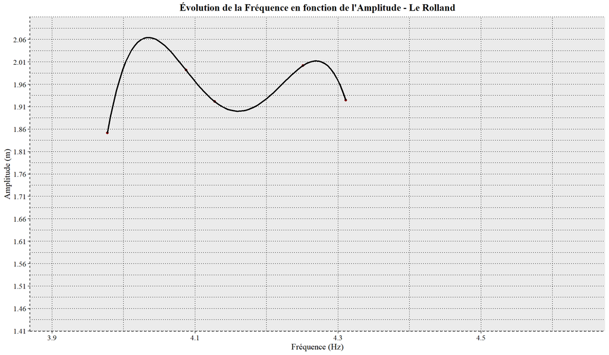

Graphique n°24 : Évolution de la Fréquence en fonction de l’Amplitude - Le Rolland

**Cumulé**

#### Profil Amplitude - Fréquence

##### Graphiques

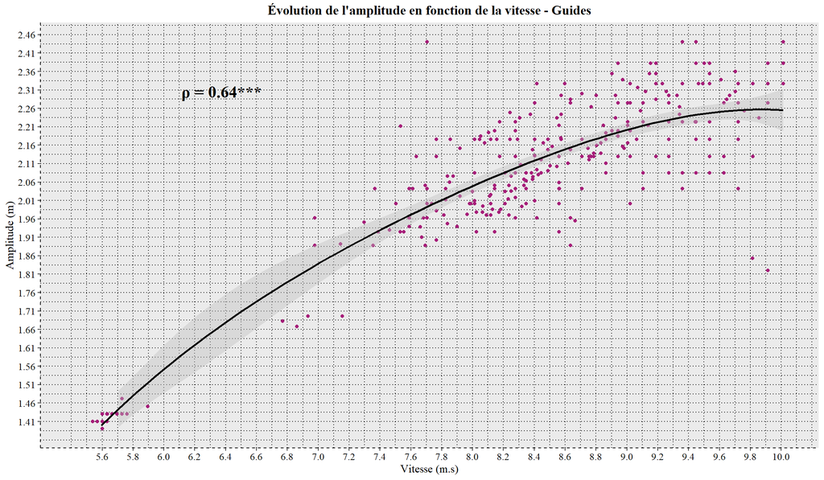

Graphique n°25 : Évolution de l’amplitude en fonction de la vitesse - Guides

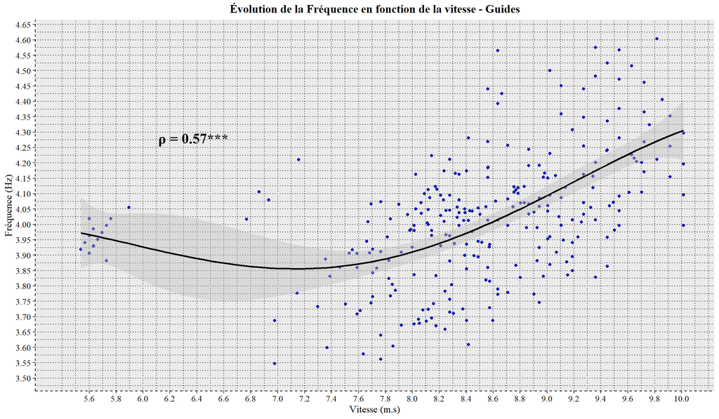

Graphique n°26 : Évolution de la Fréquence en fonction de la Vitesse - Guides

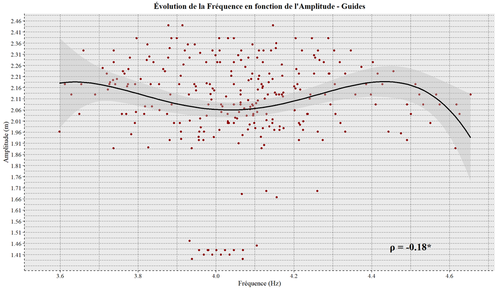

Graphique n°27: Évolution de la Fréquence en fonction de l’Amplitude - Guides

**All**

**Profil Amplitude - Fréquence**

#### Graphiques

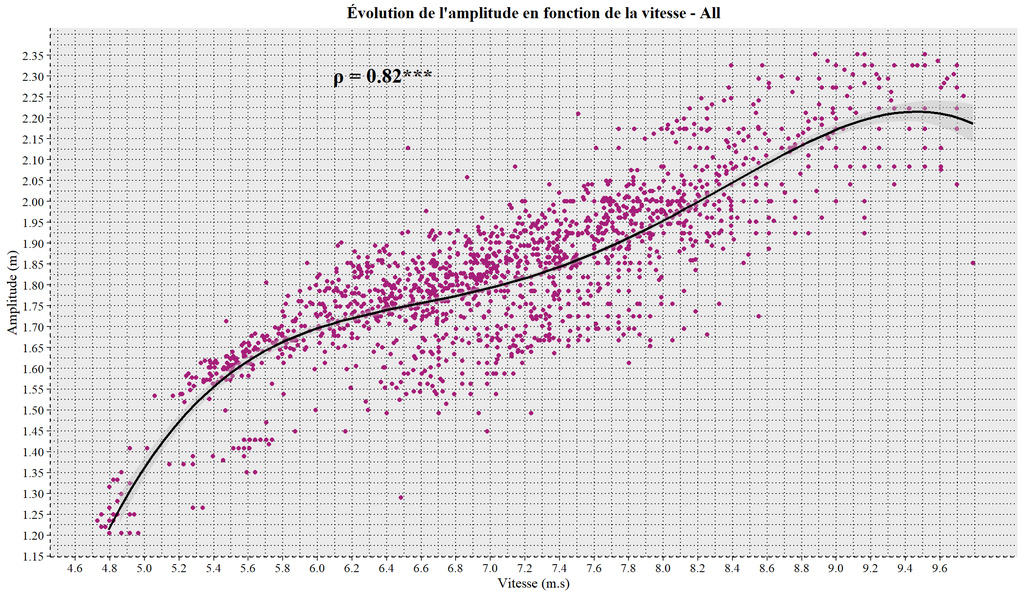

Graphique n°28 : Évolution de l’amplitude en fonction de la vitesse - All

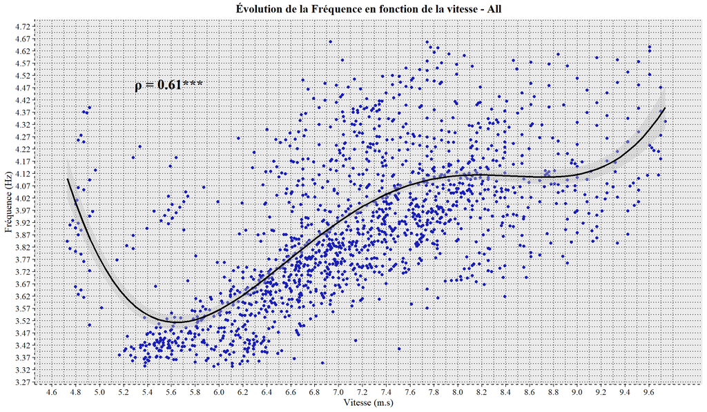

Graphique n°29 : Évolution de la Fréquence en fonction de la Vitesse - All

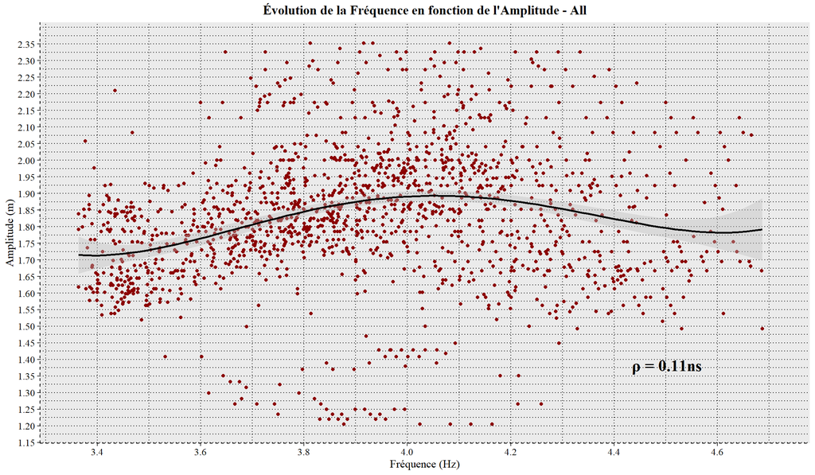

Graphique n°30 : Évolution de l’Amplitude en fonction de la Fréquence - All

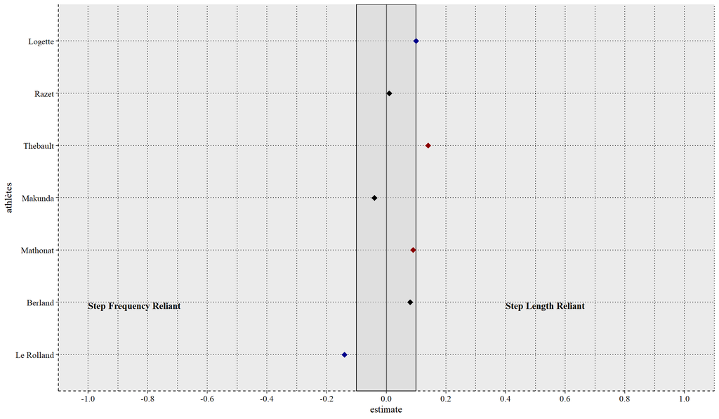

Graphique n°32 : Différence de corrélation Amplitude - Fréquence

Figure adaptée d’après *Salo & al., 2011*.

On note une différence significative vers l’amplitude pour Evan.

Les points rouges c’est les profil en force et les points bleus c’est les profils en vitesse.

On remarque que pour Evan (Thebault) ça match et pour Erwan (Le Rolland) aussi. Mais pour Lucas (Mathonat) et Tiff (Logette) ça ne match pas. Cela peut-être dû à le fouilli dans les datas de l’année dernière et de l’année d’avant. Je n’ai fait aucune distinction entre les phases de course, j’ai analysé les vidéos à la pelle, donc je pense qu’il y a un très gros biais méthodologique dans l’obtention des données des 2 dernières années chez les paras.